# Desapareguts Guerra Civil

Jose Luis Herencia

2023-12-04

##Càrrega del dataset

En primer lloc, carreguem el conjunt de dades que hem descarregat de la web https://analisi.transparenciacatalunya.cat/Legislaci-just-cia/Cens-de-persones-desaparegudes-durant-la-Guerra-Ci/u2ix-2jr6

```r
df = read.csv("./Cens_de_persones_desaparegudes_durant_la_Guerra_Civil.csv", header=TRUE, sep=";")
head(df)
```

|  | Id.Afectat | Nom.Desaparegut | Sexe | Municipi.naixement | Comarca.naixement | Província.naixement | País.estranger.naixement | Data.naixement | Període.naixement_1 | Període.naixement_2 | Municipi.habitual | Comarca.habitual | Província.habitual | És.militar | Data.mobilització | Lleva | És.voluntari | Exèrcit | Unitat.militar | Professió | Data.desaparició | Període.desaparició_1 | Període.desaparició_2 | Indret.desaparició | Comarca.desaparició | Província.desaparició | País.desaparició | És.afusellat | Data.afusellament | … |
| --- | --- | --- | --- | --- | --- | --- | --- | --- | --- | --- | --- | --- | --- | --- | --- | --- | --- | --- | --- | --- | --- | --- | --- | --- | --- | --- | --- | --- | --- | --- |
| 1 | 1 | JAM | Home | PUIGCERDÀ | Cerdanya | Girona |  |  | 1908 | 1909 |  |  |  | 1 | 1/2/1938 |  | 0 | REPUBLICÀ |  |  | 1/5/1938 | NA | NA | FRONT DE L'EBRE | Terra Alta | Tarragona | Espanya | 0 |  | … |
| 2 | 2 | FAM | Home | BARCELONA | Barcelonès | Barcelona |  | 7/1/1915 | NA | NA | BARCELONA | Barcelonès | Barcelona | 1 |  |  | 1 | REPUBLICÀ | 27 Div |  |  | 1937 | 1937 | FRONT D'ARAGÓ | z_Espanya |  | Espanya | 0 |  | … |
| 3 | 3 | JAP | Home | CUEVAS DE VERA | z_Espanya | Almeria |  |  | NA | NA | BARCELONA | Barcelonès | Barcelona | 1 | 1/12/1938 |  | 0 | REPUBLICÀ | REGIMENT INFANTERIA DEL SERRALLO 69 | BARBER | 1/12/1938 | NA | NA | RETIRADA CAP A FRANÇA |  |  |  | 0 |  | … |
| 4 | 4 | SAP | Home | UNIÓN | z_Espanya | Múrcia |  |  | NA | NA | BARCELONA | Barcelonès | Barcelona | 1 |  |  | 0 | REPUBLICÀ | 42 Div, 226 BM, 2 Bat, 2 Cia, Base TURIA 3, CC 15 |  | 1/9/1938 | NA | NA | FRONT DE L'EBRE | Terra Alta | Tarragona | Espanya | 0 |  | … |
| 5 | 5 | JAC | Home | PALANQUES | z_Espanya | Castelló |  |  | 1903 | NA | BARCELONA | Barcelonès | Barcelona | 1 |  |  | 0 | REPUBLICÀ |  | BARBER | 6/1/1939 | NA | NA | FRONT DEL SEGRE- CAP DE PONT BALAGUER | Noguera | Lleida | Espanya | 0 |  | … |
| 6 | 6 | MAN | Home | BARCELONA | Barcelonès | Barcelona |  |  | 1920 | NA |  |  |  | 1 |  |  | 0 | REPUBLICÀ |  |  |  | 1938 | NA | FRONT DE L'EBRE | Terra Alta | Tarragona | Espanya | 0 |  | … |

Seleccionem únicament les variables amb les quals treballarem

```r
if (!require("dplyr")) install.packages("dplyr")
library(dplyr)
var = c("Id.Afectat", "Sexe", "Municipi.naixement", "Comarca.naixement", "Província.naixement", "Data.naixement",
        "Període.naixement_1", "Període.naixement_2", "Municipi.habitual", "Comarca.habitual", "Província.habitual",
        "És.voluntari", "Exèrcit", "Data.desaparició", "Període.desaparició_1", "Període.desaparició_2",
        "Comarca.desaparició", "Província.desaparició", "És.afusellat", "Localitzat")
cens_df = select(df, var)
head(cens_df)
```

|  | Id.Afectat | Sexe | Municipi.naixement | Comarca.naixement | Província.naixement | Data.naixement | Període.naixement_1 | Període.naixement_2 | Municipi.habitual | Comarca.habitual | Província.habitual | És.voluntari | Exèrcit | Data.desaparició | Període.desaparició_1 | Període.desaparició_2 | Comarca.desaparició | Província.desaparició | És.afusellat | Localitzat |
| --- | --- | --- | --- | --- | --- | --- | --- | --- | --- | --- | --- | --- | --- | --- | --- | --- | --- | --- | --- | --- |
| 1 | 1 | Home | PUIGCERDÀ | Cerdanya | Girona |  | 1908 | 1909 |  |  |  | 0 | REPUBLICÀ | 1/5/1938 | NA | NA | Terra Alta | Tarragona | 0 | 0 |
| 2 | 2 | Home | BARCELONA | Barcelonès | Barcelona | 7/1/1915 | NA | NA | BARCELONA | Barcelonès | Barcelona | 1 | REPUBLICÀ |  | 1937 | 1937 | z_Espanya |  | 0 | 0 |
| 3 | 3 | Home | CUEVAS DE VERA | z_Espanya | Almeria |  | NA | NA | BARCELONA | Barcelonès | Barcelona | 0 | REPUBLICÀ | 1/12/1938 | NA | NA |  |  | 0 | 0 |
| 4 | 4 | Home | UNIÓN | z_Espanya | Múrcia |  | NA | NA | BARCELONA | Barcelonès | Barcelona | 0 | REPUBLICÀ | 1/9/1938 | NA | NA | Terra Alta | Tarragona | 0 | 0 |
| 5 | 5 | Home | PALANQUES | z_Espanya | Castelló |  | 1903 | NA | BARCELONA | Barcelonès | Barcelona | 0 | REPUBLICÀ | 6/1/1939 | NA | NA | Noguera | Lleida | 0 | 0 |
| 6 | 6 | Home | BARCELONA | Barcelonès | Barcelona |  | 1920 | NA |  |  |  | 0 | REPUBLICÀ |  | 1938 | NA | Terra Alta | Tarragona | 0 | 0 |

Visualitzem un detall dels estadístics de totes les variables

```r
summary(cens_df)
```

```
##    Id.Afectat       Sexe           Municipi.naixement Comarca.naixement
##  Min.   :   1   Length:5307        Length:5307        Length:5307
##  1st Qu.:1330   Class :character   Class :character   Class :character
##  Median :2657   Mode  :character   Mode  :character   Mode  :character
##  Mean   :2656
##  3rd Qu.:3984
##  Max.   :5310
##
##  Província.naixement Data.naixement     Període.naixement_1 Període.naixement_2
##  Length:5307         Length:5307        Min.   :1090        Min.   : 1868
##  Class :character    Class :character   1st Qu.:1903        1st Qu.: 1907
##  Mode  :character    Mode  :character   Median :1910        Median : 1915
##                                         Mean   :1908        Mean   : 1951
##                                         3rd Qu.:1917        3rd Qu.: 1920
##                                         Max.   :1981        Max.   :19119
##                                         NA's   :3344        NA's   :4857
##  Municipi.habitual  Comarca.habitual   Província.habitual  És.voluntari
##  Length:5307        Length:5307        Length:5307        Min.   :0.00000
##  Class :character   Class :character   Class :character   1st Qu.:0.00000
##  Mode  :character   Mode  :character   Mode  :character   Median :0.00000
##                                                           Mean   :0.03128
##                                                           3rd Qu.:0.00000
##                                                           Max.   :1.00000
##
##    Exèrcit          Data.desaparició   Període.desaparició_1
##  Length:5307        Length:5307        Min.   :1929
##  Class :character   Class :character   1st Qu.:1938
##  Mode  :character   Mode  :character   Median :1938
##                                        Mean   :1938
##                                        3rd Qu.:1938
##                                        Max.   :1968
##                                        NA's   :3554
##  Període.desaparició_2 Comarca.desaparició Província.desaparició
##  Min.   :1930          Length:5307         Length:5307
##  1st Qu.:1938          Class :character    Class :character
##  Median :1939          Mode  :character    Mode  :character
##  Mean   :1939
##  3rd Qu.:1939
##  Max.   :1965
##  NA's   :4895
##   És.afusellat       Localitzat
##  Min.   :0.00000   Min.   :0.000
##  1st Qu.:0.00000   1st Qu.:0.000
##  Median :0.00000   Median :0.000
##  Mean   :0.05408   Mean   :0.111
##  3rd Qu.:0.00000   3rd Qu.:0.000
##  Max.   :1.00000   Max.   :1.000
##
```

Canviem el nom de les columnes per eliminar els punts i fer més accessibles les variables.

```r
colnames(cens_df) = c('id', 'sexe', 'mun_naix', 'comarca_naix', 'prov_naix', 'data_naix', 'per_naix_1', 'per_naix_2', 'mun_hab', 'comarca_hab', 'prov_hab', 'voluntari', 'exercit', 'data_des', 'per_des_1', 'per_des_2', 'comarca_des', 'prov_des', 'afusellat', 'localitzat')
```

Convertim en variables categòriques les variables ‘sexe’, ‘voluntari’, ‘exercit’, ‘afusellat’ i ‘localitzat’.

```r
cens_df$sexe = as.factor(cens_df$sexe)
cens_df$voluntari = as.factor(cens_df$voluntari)
cens_df$exercit = as.factor(cens_df$exercit)
cens_df$afusellat = as.factor(cens_df$afusellat)
cens_df$localitzat = as.factor(cens_df$localitzat)
summary(cens_df)
```

```
##        id         sexe        mun_naix         comarca_naix
##  Min.   :   1   Dona: 129   Length:5307        Length:5307
##  1st Qu.:1330   Home:5178   Class :character   Class :character
##  Median :2657               Mode  :character   Mode  :character
##  Mean   :2656
##  3rd Qu.:3984
##  Max.   :5310
##
##   prov_naix          data_naix           per_naix_1     per_naix_2
##  Length:5307        Length:5307        Min.   :1090   Min.   : 1868
##  Class :character   Class :character   1st Qu.:1903   1st Qu.: 1907
##  Mode  :character   Mode  :character   Median :1910   Median : 1915
##                                        Mean   :1908   Mean   : 1951
##                                        3rd Qu.:1917   3rd Qu.: 1920
##                                        Max.   :1981   Max.   :19119
##                                        NA's   :3344   NA's   :4857
##    mun_hab          comarca_hab          prov_hab         voluntari
##  Length:5307        Length:5307        Length:5307        0:5141
##  Class :character   Class :character   Class :character   1: 166
##  Mode  :character   Mode  :character   Mode  :character
##
##
##
##
##       exercit       data_des           per_des_1      per_des_2
##           :1773   Length:5307        Min.   :1929   Min.   :1930
##  REBEL    : 139   Class :character   1st Qu.:1938   1st Qu.:1938
##  REPUBLICÀ:3395   Mode  :character   Median :1938   Median :1939
##                                      Mean   :1938   Mean   :1939
##                                      3rd Qu.:1938   3rd Qu.:1939
##                                      Max.   :1968   Max.   :1965
##                                      NA's   :3554   NA's   :4895
##  comarca_des          prov_des         afusellat localitzat
##  Length:5307        Length:5307        0:5020    0:4718
##  Class :character   Class :character   1: 287    1: 589
##  Mode  :character   Mode  :character
##
##
##
##
```

Podem veure que les úniques variables amb valors nuls son per_naix_1, per_naix_2, per_des_1 i per_des_2, mentre que a més, la variable exercit conté valors en blanc. Per les variables categòriques ‘sexe’, ‘voluntari’, ‘afusellat’ i ‘localitzat’ tots els valors estan informats sota una de les dues categories correctes (home/dona i 0-false/1-true).

Mitjançant gràfics comprovem que les variables ‘sexe’, ‘voluntari’, ‘afusellat’ i ‘localitzat’ contenen els valors correctes. Abans però, canviem les etiquetes de les categories 0 per false i 1 per true a les variables corresponents.

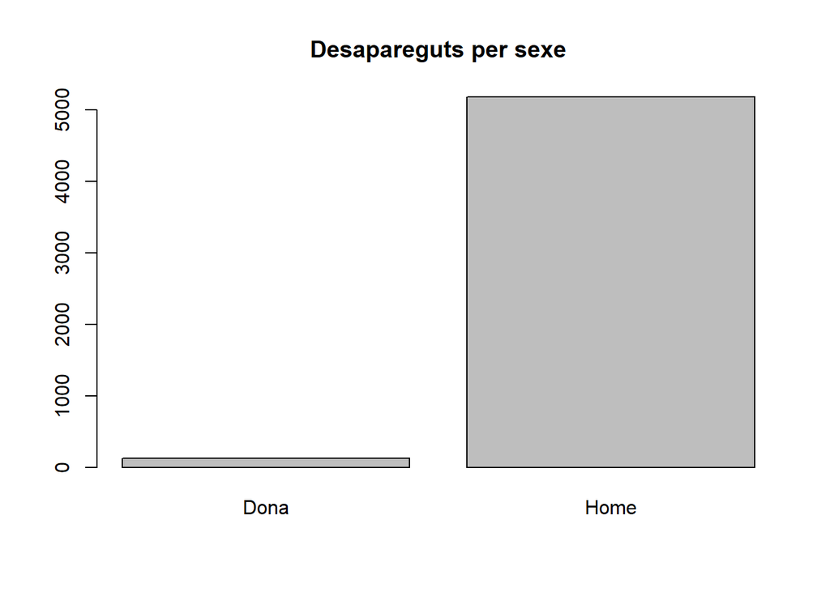

```r
levels(cens_df$voluntari) = c("false", "true")
levels(cens_df$afusellat) = c("false", "true")
levels(cens_df$localitzat) = c("false", "true")
plot(x=cens_df$sexe, main="Desapareguts per sexe")
```

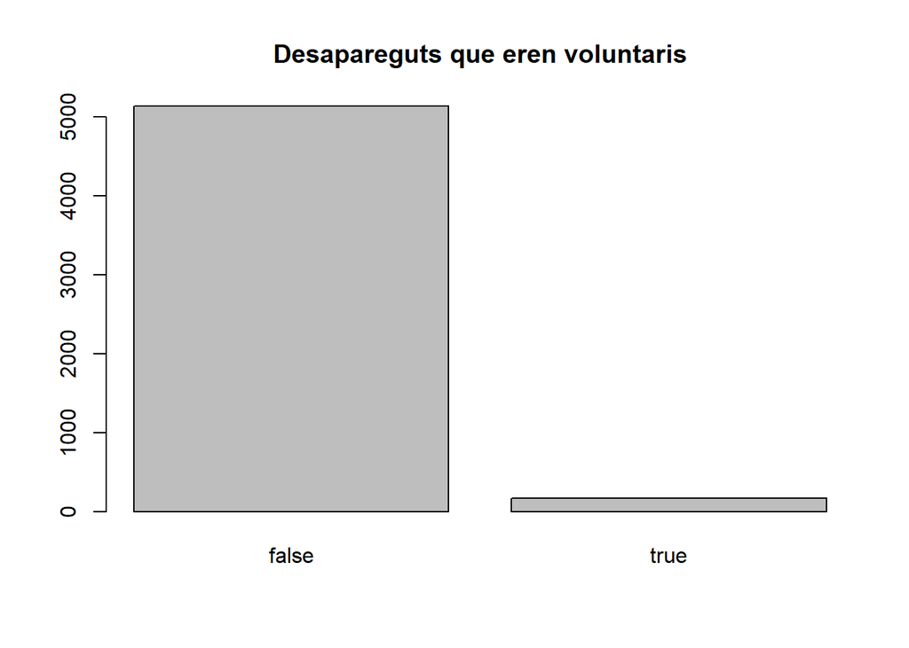

```r
plot(x=cens_df$voluntari, main="Desapareguts que eren voluntaris")
```

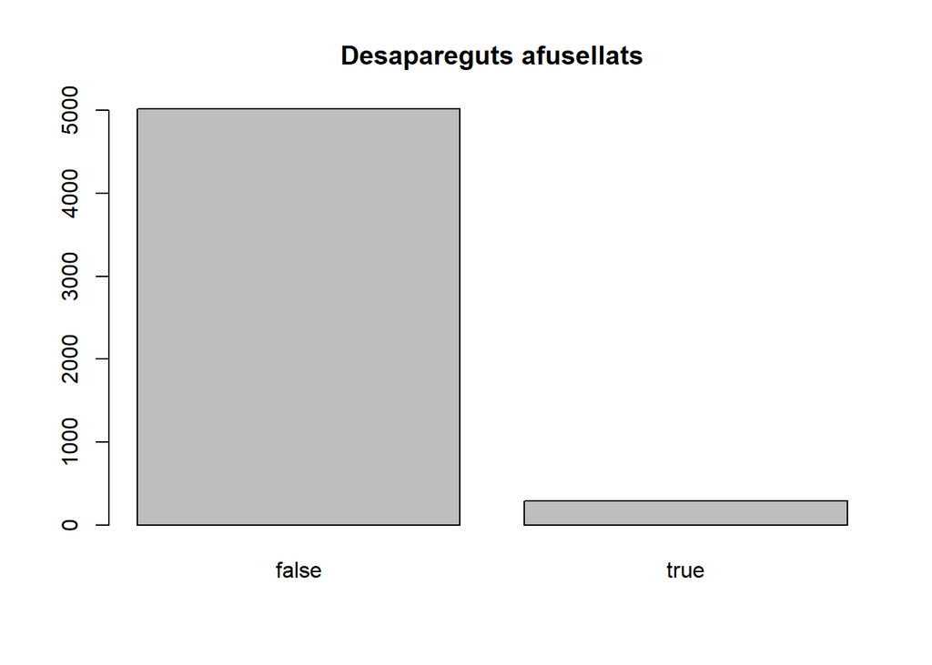

```r
plot(x=cens_df$afusellat, main="Desapareguts afusellats")
```

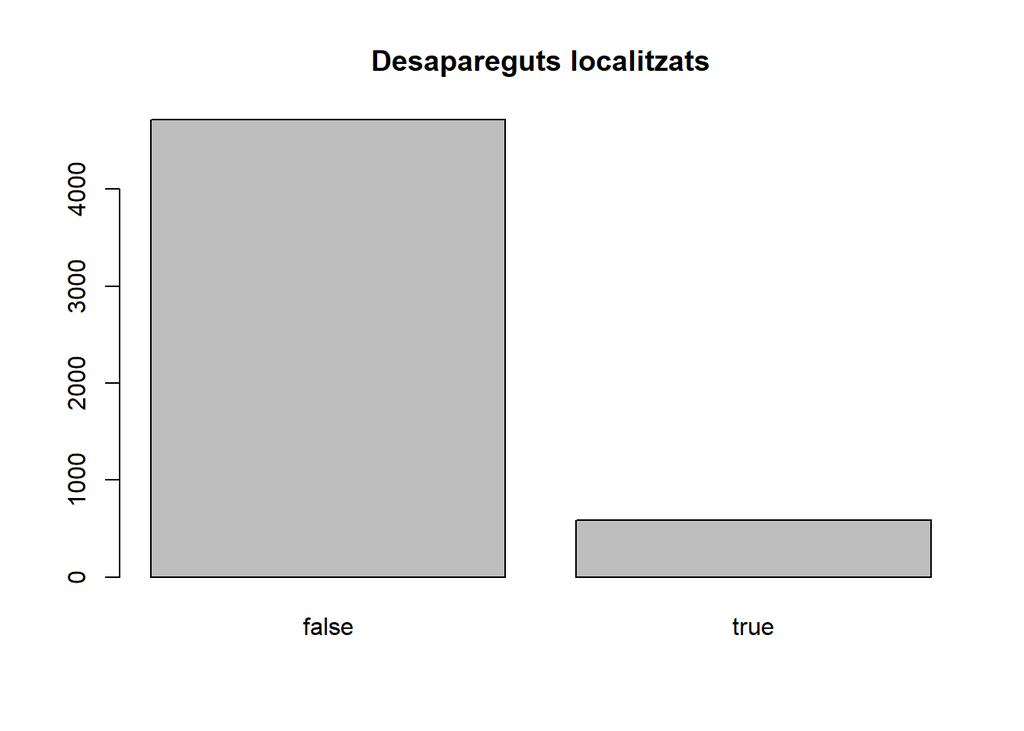

```r
plot(x=cens_df$localitzat, main="Desapareguts localitzats")
```

Ara explorem les variables data_naix i data_des, conjuntament amb per_naix_1, per_naix_2, per_des_1 i per_des_2. Per a estudiar els anys en què més desaparicions es van produir, o l’edat mitjana en desaparèixer, farem una aproximació mitjançant el per_naix_1, per_naix_2, data_naix, data_des, per_des_1 i per_des_2. Veiem que tenim valors buits en aquests casos. Per tant, el primer que farem serà crear dues noves variables (any_naix i any_des) que es nodriran en primer lloc del valor data_naix o data_des, si estan buits per_naix_1/per_des_1, si també estan buits del per_naix_2/per_des_2

```r
cens_df$any_naix=as.integer(substr(cens_df$data_naix, nchar(cens_df$data_naix)-3, nchar(cens_df$data_naix)))
cens_df$any_des=as.integer(substr(cens_df$data_des, nchar(cens_df$data_des)-3, nchar(cens_df$data_des)))
for (i in cens_df$id){
  if (is.na(cens_df[i,"any_naix"])){
    cens_df[i,"any_naix"]=as.integer(cens_df[i,"per_naix_1"])
  }
  if (is.na(cens_df[i,"any_des"])){
    cens_df[i, "any_des"]=as.integer(cens_df[i,"per_des_1"])
  }
}
cens_df$any_naix[is.na(cens_df$any_naix)]=cens_df$per_naix_2
cens_df$any_des[is.na(cens_df$any_des)]=cens_df$per_des_2
```

Pel que fa a l’any de desaparició, pels que no la coneixem informarem com any l’inici de la Guerra Civil, és a dir, 1936.

```r
cens_df$any_des[is.na(cens_df$any_des)]=1936
```

Abans de crear la variable edat, representem les variables any_des i any_naix en boxplots per comprovar si hi ha valors atípics.

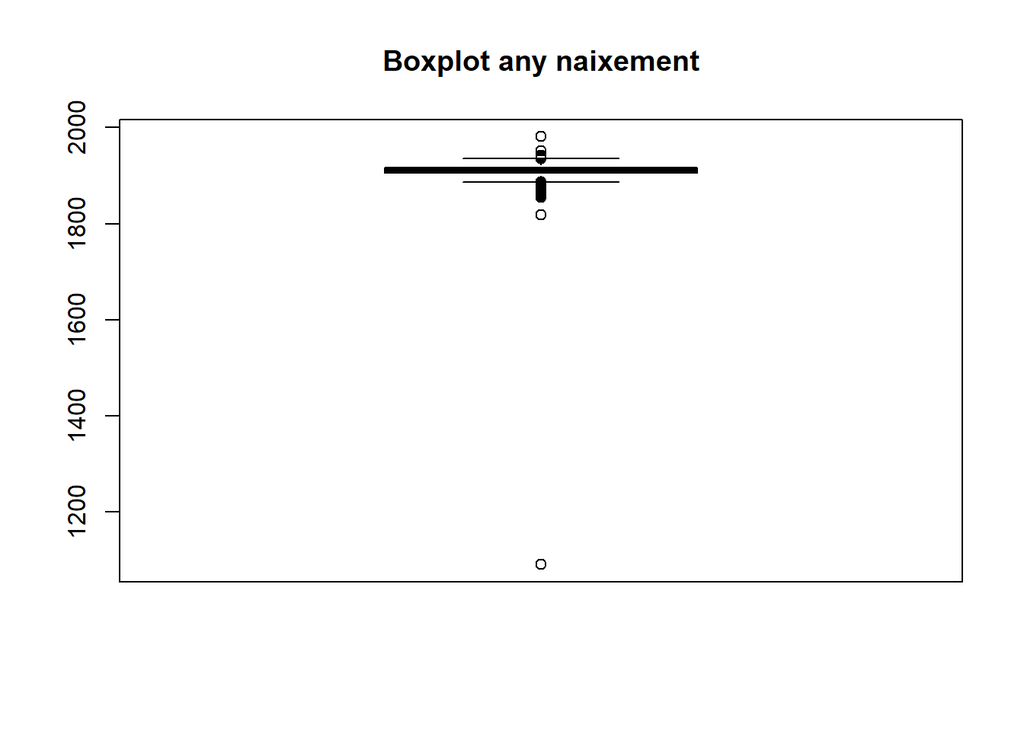

```r
boxplot(cens_df$any_naix, main="Boxplot any naixement")
```

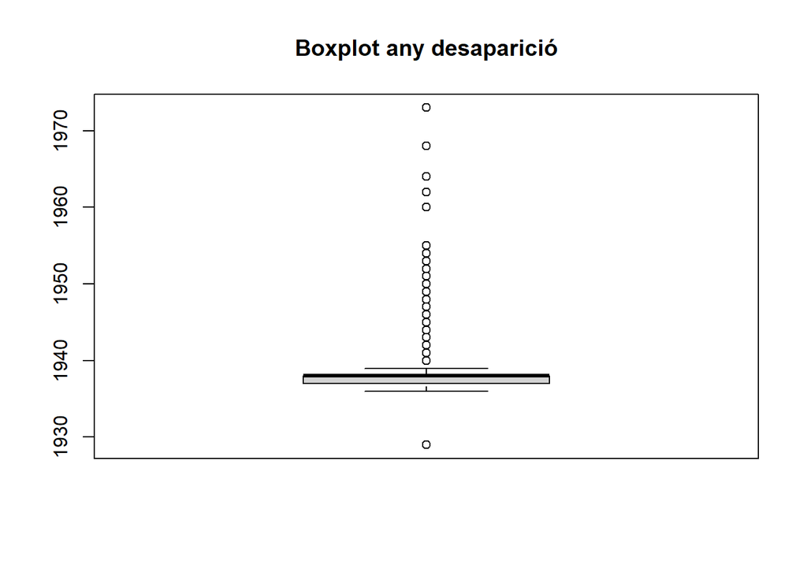

```r
boxplot(cens_df$any_des, main="Boxplot any desaparició")
```

Observem valors atípics, tant a l’any de naixement com de desaparició.

```r
summary(cens_df$any_naix)
```

```
##    Min. 1st Qu.  Median    Mean 3rd Qu.    Max.    NA's
##    1090    1905    1910    1910    1917    1981     866
```

```r
summary(cens_df$any_des)
```

```
##    Min. 1st Qu.  Median    Mean 3rd Qu.    Max.
##    1929    1937    1938    1938    1938    1973
```

Veiem que l’outlier correspon a l’any de naixement 1090. Ha de tractar-se d’una errada a l’introduir les dades, i l’any correcte presumiblement sigui 1900. Per tant, el substituim.

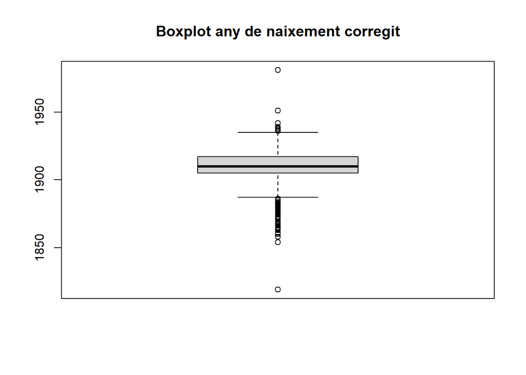

```r
cens_df$any_naix[cens_df$any_naix==1090] = 1900
boxplot(cens_df$any_naix, main="Boxplot any de naixement corregit")
```

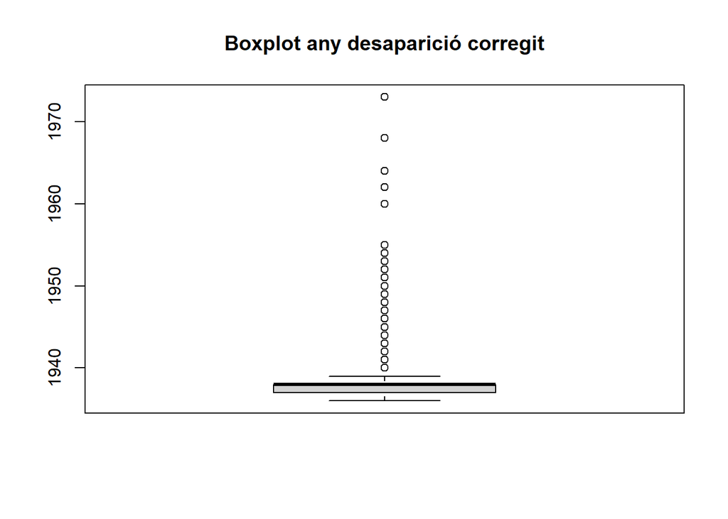

```r
cens_df$any_des[cens_df$any_des<1936] = 1936
boxplot(cens_df$any_des, main= "Boxplot any desaparició corregit")
```

Ara calculem la variable edat, que a més, ens servirà per veure si els anys de naixement i desaparició son coherents entre si (any desaparició no pot ser anterior a any de naixement, i per tant, resultaria en una edat negativa)

```r
cens_df$edat = cens_df$any_des-cens_df$any_naix
summary(cens_df$edat)
```

```
##    Min. 1st Qu.  Median    Mean 3rd Qu.    Max.    NA's
##  -42.00   21.00   27.00   28.04   33.00  120.00     866
```

Efectivament, observem que hi ha edats negatives. Busquem aquests registres.

```r
cens_df[cens_df$edat<0 & !is.na(cens_df$edat), ]
```

|  | id | sexe | mun_naix | comarca_naix | prov_naix | data_naix | per_naix_1 | per_naix_2 | mun_hab | comarca_hab | prov_hab | voluntari | exercit | data_des | per_des_1 | per_des_2 | comarca_des | prov_des | afusellat | localitzat | any_naix | any_des | edat |
| --- | --- | --- | --- | --- | --- | --- | --- | --- | --- | --- | --- | --- | --- | --- | --- | --- | --- | --- | --- | --- | --- | --- | --- |
| 2266 | 2256 | Home | ALGUAIRE | Segrià | Lleida |  | 1981 | 1892 | ALGUAIRE | Segrià | Lleida | false |  | 1/6/1939 | NA | NA | Segrià | Lleida | true | true | 1981 | 1939 | -42 |
| 4528 | 4525 | Home | BARCELONA | Barcelonès | Barcelona | 16/2/1942 | NA | NA | BARCELONA | Barcelonès | Barcelona | false |  |  | NA | NA | Barcelonès | Barcelona | false | false | 1942 | 1936 | -6 |
| 4645 | 4644 | Home | MUNERA | z_Espanya | Albacete | 19/3/1938 | NA | NA |  |  |  | false | REPUBLICÀ |  | NA | 1938 |  |  | false | false | 1938 | 1936 | -2 |
| 4757 | 4756 | Home | VANDELLÓS | Baix Camp | Tarragona | 16/2/1939 | NA | NA | VANDELLÓS | Baix Camp | Tarragona | false | REPUBLICÀ |  | NA | NA |  |  | false | false | 1939 | 1936 | -3 |

Veiem que són únicament 4 registres, tres dels quals la causa ha estat que no es coneixia l’any de desaparició, i per tant s’ha informat 1936. L’altre cas es tracta d’un any de naixement erroni (1981) que molt probablement es tracti de 1891. Canviem aquest cas, i els altres tres registres els eliminarem.

```r
cens_df$any_naix[cens_df$edat == -42] = 1891
cens_df$edat = cens_df$any_des-cens_df$any_naix
cens_df = cens_df[cens_df$id != 4525 & cens_df$id !=4644 & cens_df$id != 4756, ]
summary(cens_df)
```

```
##        id         sexe        mun_naix         comarca_naix
##  Min.   :   1   Dona: 129   Length:5307        Length:5307
##  1st Qu.:1330   Home:5175   Class :character   Class :character
##  Median :2656   NA's:   3   Mode  :character   Mode  :character
##  Mean   :2655
##  3rd Qu.:3981
##  Max.   :5310
##  NA's   :3
##   prov_naix          data_naix           per_naix_1     per_naix_2
##  Length:5307        Length:5307        Min.   :1090   Min.   : 1868
##  Class :character   Class :character   1st Qu.:1903   1st Qu.: 1907
##  Mode  :character   Mode  :character   Median :1910   Median : 1915
##                                        Mean   :1908   Mean   : 1951
##                                        3rd Qu.:1917   3rd Qu.: 1920
##                                        Max.   :1981   Max.   :19119
##                                        NA's   :3344   NA's   :4857
##    mun_hab          comarca_hab          prov_hab         voluntari
##  Length:5307        Length:5307        Length:5307        false:5138
##  Class :character   Class :character   Class :character   true : 166
##  Mode  :character   Mode  :character   Mode  :character   NA's :   3
##
##
##
##
##       exercit       data_des           per_des_1      per_des_2
##           :1772   Length:5307        Min.   :1929   Min.   :1930
##  REBEL    : 139   Class :character   1st Qu.:1938   1st Qu.:1938
##  REPUBLICÀ:3393   Mode  :character   Median :1938   Median :1939
##  NA's     :   3                      Mean   :1938   Mean   :1939
##                                      3rd Qu.:1938   3rd Qu.:1939
##                                      Max.   :1968   Max.   :1965
##                                      NA's   :3554   NA's   :4896
##  comarca_des          prov_des         afusellat    localitzat      any_naix
##  Length:5307        Length:5307        false:5017   false:4715   Min.   :1819
##  Class :character   Class :character   true : 287   true : 589   1st Qu.:1905
##  Mode  :character   Mode  :character   NA's :   3   NA's :   3   Median :1910
##                                                                  Mean   :1910
##                                                                  3rd Qu.:1917
##                                                                  Max.   :1951
##                                                                  NA's   :866
##     any_des          edat
##  Min.   :1936   Min.   :  0.00
##  1st Qu.:1937   1st Qu.: 21.00
##  Median :1938   Median : 27.00
##  Mean   :1938   Mean   : 28.08
##  3rd Qu.:1938   3rd Qu.: 33.00
##  Max.   :1973   Max.   :120.00
##  NA's   :3      NA's   :866
```

Observem 3 registres amb tots els valors ‘NA’. Eliminem aquests registres, i aprofitem per eliminar les variables amb les quals ja no treballarem (data naixement, periode_1, …) i les reordenem

```r
vars = c("id", "sexe", "any_naix", "any_des", "edat", "mun_naix", "comarca_naix", "prov_naix", "mun_hab", "comarca_hab", "prov_hab", "comarca_des", "prov_des", "voluntari", "exercit", "afusellat", "localitzat")
cens_df = cens_df[!is.na(cens_df$id), ]
cens_df = cens_df[vars]
summary(cens_df)
```

```
##        id         sexe         any_naix       any_des          edat
##  Min.   :   1   Dona: 129   Min.   :1819   Min.   :1936   Min.   :  0.00
##  1st Qu.:1330   Home:5175   1st Qu.:1905   1st Qu.:1937   1st Qu.: 21.00
##  Median :2656               Median :1910   Median :1938   Median : 27.00
##  Mean   :2655               Mean   :1910   Mean   :1938   Mean   : 28.08
##  3rd Qu.:3981               3rd Qu.:1917   3rd Qu.:1938   3rd Qu.: 33.00
##  Max.   :5310               Max.   :1951   Max.   :1973   Max.   :120.00
##                             NA's   :863                   NA's   :863
##    mun_naix         comarca_naix        prov_naix           mun_hab
##  Length:5304        Length:5304        Length:5304        Length:5304
##  Class :character   Class :character   Class :character   Class :character
##  Mode  :character   Mode  :character   Mode  :character   Mode  :character
##
##
##
##
##  comarca_hab          prov_hab         comarca_des          prov_des
##  Length:5304        Length:5304        Length:5304        Length:5304
##  Class :character   Class :character   Class :character   Class :character
##  Mode  :character   Mode  :character   Mode  :character   Mode  :character
##
##
##
##
##  voluntari         exercit     afusellat    localitzat
##  false:5138            :1772   false:5017   false:4715
##  true : 166   REBEL    : 139   true : 287   true : 589
##               REPUBLICÀ:3393
##
##
##
##
```

Observem que les variables categòriques ‘afusellat’, ‘localitzat’ i ‘voluntari’ no presenten problemes. Però no és així amb ‘exercit’, on hi ha 1772 sense informar. Representem aquests registres per veure si podem treure alguna conclusió.

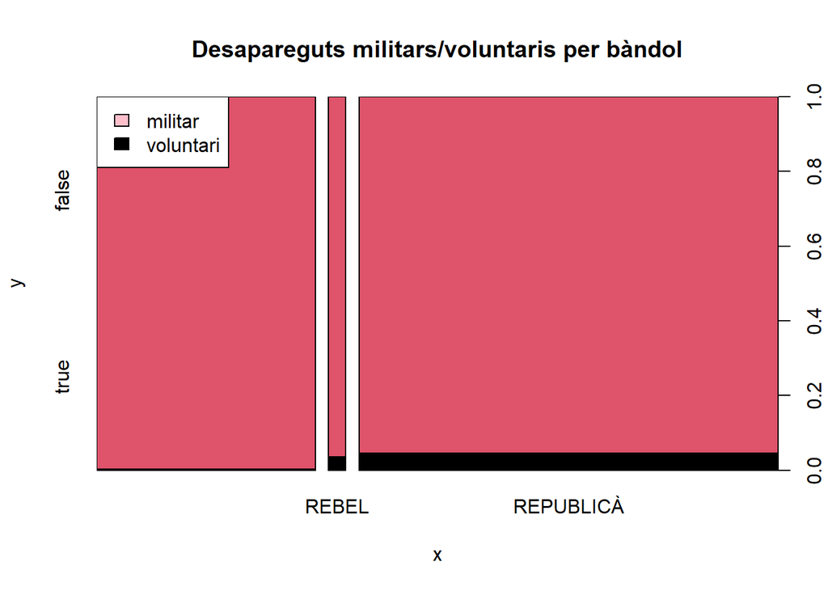

```r
plot(cens_df$exercit, cens_df$voluntari, main="Desapareguts militars/voluntaris per bàndol", col=cens_df$voluntari)
legend("topleft", legend=c("militar", "voluntari"), fill=c("pink", "black"))
```

A primera vista sembla que les proporcions son similars en ambdos bàndols, i què el bàndol sense identificar també té registres de les dues categories. Per tant, el que farem serà identificar tots aquests com “ES DESCONEIX”. Per això, canviem l’etiqueta

```r
levels(cens_df$exercit)=c("ES DESCONEIX", "REBEL", "REPUBLICÀ")
cens_df$exercit[is.na(cens_df$exercit)] = "ES DESCONEIX"
summary(cens_df$exercit)
```

```
## ES DESCONEIX        REBEL    REPUBLICÀ
##         1772          139         3393
```

Finalment, només ens queda comprovar les variables relatives a municipi, comarca i província, tant de naixement com habitual o de desaparició. El primer que farem, per evitar duplicitats, serà passar-ho tot a majúscules.

```r
cens_df$mun_hab=toupper(cens_df$mun_hab)
cens_df$mun_naix=toupper(cens_df$mun_naix)
cens_df$comarca_des=toupper(cens_df$comarca_des)
cens_df$comarca_hab=toupper(cens_df$comarca_hab)
cens_df$comarca_naix=toupper(cens_df$comarca_naix)
cens_df$prov_des=toupper(cens_df$prov_des)
cens_df$prov_hab=toupper(cens_df$prov_hab)
cens_df$prov_naix=toupper(cens_df$prov_naix)
```

A continuació comprovem els valors únics per províncies i comarques.

```r
sort(unique(cens_df$comarca_des))
```

```
##  [1] ""                  "ALT CAMP"          "ALT EMPORDÀ"
##  [4] "ALT PENEDÈS"       "ALT URGELL"        "ALTA RIBAGORÇA"
##  [7] "ANOIA"             "BAGES"             "BAIX CAMP"
## [10] "BAIX EBRE"         "BAIX EMPORDÀ"      "BAIX LLOBREGAT"
## [13] "BAIX PENEDÈS"      "BARCELONÈS"        "BERGUEDÀ"
## [16] "CERDANYA"          "CONCA DE BARBERÀ"  "GARRAF"
## [19] "GARRIGUES"         "GARROTXA"          "GIRONÈS"
## [22] "MARESME"           "MONTSIÀ"           "NOGUERA"
## [25] "OSONA"             "PALLARS JUSSÀ"     "PALLARS SOBIRÀ"
## [28] "PLA D'URGELL"      "PLA DE L'ESTANY"   "PRIORAT"
## [31] "RIBERA D'EBRE"     "RIPOLLÈS"          "SEGARRA"
## [34] "SEGRIÀ"            "SELVA"             "SOLSONÈS"
## [37] "TARRAGONÈS"        "TERRA ALTA"        "URGELL"
## [40] "VAL D'ARAN"        "VALLÈS OCCIDENTAL" "VALLÈS ORIENTAL"
## [43] "Z_ESPANYA"         "Z_FORA ESPANYA"
```

```r
sort(unique(cens_df$comarca_hab))
```

```
##  [1] ""                  "ALT CAMP"          "ALT EMPORDÀ"
##  [4] "ALT PENEDÈS"       "ALT URGELL"        "ALTA RIBAGORÇA"
##  [7] "ANOIA"             "BAGES"             "BAIX CAMP"
## [10] "BAIX EBRE"         "BAIX EMPORDÀ"      "BAIX LLOBREGAT"
## [13] "BAIX PENEDÈS"      "BARCELONÈS"        "BERGUEDÀ"
## [16] "CERDANYA"          "CONCA DE BARBERÀ"  "GARRAF"
## [19] "GARRIGUES"         "GARROTXA"          "GIRONÈS"
## [22] "MARESME"           "MONTSIÀ"           "NOGUERA"
## [25] "OSONA"             "PALLARS JUSSÀ"     "PALLARS SOBIRÀ"
## [28] "PLA D'URGEL"       "PLA DE L'ESTANY"   "PRIORAT"
## [31] "RIBERA D'EBRE"     "RIPOLLÈS"          "SEGARRA"
## [34] "SEGRIÀ"            "SELVA"             "SOLSONÈS"
## [37] "TARRAGONÈS"        "TERRA ALTA"        "URGELL"
## [40] "VAL D'ARAN"        "VALLÈS OCCIDENTAL" "VALLÈS ORIENTAL"
## [43] "Z_ESPANYA"         "Z_FORA ESPANYA"
```

```r
sort(unique(cens_df$comarca_naix))
```

```
##  [1] ""                  "ALT CAMP"          "ALT EMPORDÀ"
##  [4] "ALT PENEDÈS"       "ALT URGELL"        "ALTA RIBAGORÇA"
##  [7] "ANOIA"             "BAGES"             "BAIX CAMP"
## [10] "BAIX EBRE"         "BAIX EMPORDÀ"      "BAIX LLOBREGAT"
## [13] "BAIX PENEDÈS"      "BARCELONÈS"        "BERGUEDÀ"
## [16] "CERDANYA"          "CONCA DE BARBERÀ"  "GARRAF"
## [19] "GARRIGUES"         "GARROTXA"          "GIRONÈS"
## [22] "MARESME"           "MONTSIÀ"           "NOGUERA"
## [25] "OSONA"             "PALLARS JUSSÀ"     "PALLARS SOBIRÀ"
## [28] "PLA D'URGEL"       "PLA DE L'ESTANY"   "PRIORAT"
## [31] "RIBERA D'EBRE"     "RIPOLLÈS"          "SEGARRA"
## [34] "SEGRIÀ"            "SELVA"             "SOLSONÈS"
## [37] "TARRAGONÈS"        "TERRA ALTA"        "URGELL"
## [40] "VALLÈS OCCIDENTAL" "VALLÈS ORIENTAL"   "Z_ESPANYA"
## [43] "Z_FORA ESPANYA"
```

Observem els mateixos valors en totes tres variables relacionades amb la comarca. Únicament ens trobem amb el fet que, no existeix cap nascut a la Val d’Aran, la qual cosa no ens suposa cap problema, i que el Pla d’Urgell està informat com a Pla d’Urgel (amb una sola L) a comarca habitual i de naixement. Farem aquest canvi per unificar el nom. També comprovarem les comarques buides (““) a que corresponen.

```r
cens_df$comarca_hab[cens_df$comarca_hab=="PLA D'URGEL"] = "PLA D'URGELL"
cens_df$comarca_naix[cens_df$comarca_naix=="PLA D'URGEL"] = "PLA D'URGELL"
cens_df[cens_df$comarca_hab=="", ]
```

|  | id | sexe | any_naix | any_des | edat | mun_naix | comarca_naix | prov_naix | mun_hab | comarca_hab | prov_hab | comarca_des | prov_des | voluntari | exercit | afusellat | localitzat |
| --- | --- | --- | --- | --- | --- | --- | --- | --- | --- | --- | --- | --- | --- | --- | --- | --- | --- |
| 1 | 1 | Home | 1908 | 1938 | 30 | PUIGCERDÀ | CERDANYA | GIRONA |  |  |  | TERRA ALTA | TARRAGONA | false | REPUBLICÀ | false | false |
| 6 | 6 | Home | 1920 | 1938 | 18 | BARCELONA | BARCELONÈS | BARCELONA |  |  |  | TERRA ALTA | TARRAGONA | false | REPUBLICÀ | false | false |
| 7 | 7 | Home | NA | 1938 | NA | SABADELL | VALLÈS OCCIDENTAL | BARCELONA |  |  |  | Z_ESPANYA | TEROL | false | REBEL | false | false |
| 13 | 13 | Home | NA | 1938 | NA | SAMA DE LANGREO | Z_ESPANYA | ASTÚRIES |  |  |  | Z_ESPANYA | ASTÚRIES | false | ES DESCONEIX | false | true |
| 15 | 15 | Home | 1906 | 1938 | 32 | FORTIÀ | ALT EMPORDÀ | GIRONA |  |  |  | PALLARS JUSSÀ | LLEIDA | false | REPUBLICÀ | false | false |
| 17 | 17 | Home | NA | 1939 | NA | MONROYO | Z_ESPANYA | TEROL |  |  |  | SEGRIÀ | LLEIDA | false | REPUBLICÀ | false | false |
| 19 | 19 | Home | NA | 1939 | NA | CABDET | Z_ESPANYA | ALBACETE |  |  |  | VALLÈS OCCIDENTAL | BARCELONA | false | ES DESCONEIX | false | false |
| 21 | 21 | Home | 1912 | 1938 | 26 | BARCELONA | BARCELONÈS | BARCELONA |  |  |  | Z_ESPANYA | OSCA | false | REPUBLICÀ | false | false |
| 24 | 24 | Home | NA | 1936 | NA | VADOCONDES | Z_ESPANYA | BURGOS |  |  |  | Z_ESPANYA | BURGOS | false | ES DESCONEIX | false | false |
| 47 | 47 | Home | 1910 | 1936 | 26 | SÉNIA | MONTSIÀ | TARRAGONA |  |  |  | Z_ESPANYA | TEROL | false | REPUBLICÀ | false | false |

[output cut: 693 more lines]

En el cas que comarca habitual està buit, es perquè ni el municipi ni la província habituals estan informats. En aquest cas, informarem com a comarca habitual, municipi habitual i província habitual els mateixos informats com de naixement. Però sempre i quan aquests 3 camps estiguin buits.

```r
for(i in cens_df$id){
  if(cens_df$mun_hab[cens_df$id==i]=="" &
     cens_df$comarca_hab[cens_df$id==i]=="" &
     cens_df$prov_hab[cens_df$id==i]==""){
    cens_df$mun_hab[cens_df$id==i]=cens_df$mun_naix[cens_df$id==i]
    cens_df$comarca_hab[cens_df$id==i]=cens_df$comarca_naix[cens_df$id==i]
    cens_df$prov_hab[cens_df$id==i]=cens_df$prov_naix[cens_df$id==i]
  }
}
```

Ara comprovem les províncies.

```r
sort(unique(cens_df$prov_des))
```

```
##  [1] ""              "ALACANT"       "ALBACETE"      "ALMERIA"
##  [5] "ASTÚRIES"      "BADAJOZ"       "BARCELONA"     "BISCAIA"
##  [9] "BURGOS"        "CÀCERES"       "CADIS"         "CANTÀBRIA"
## [13] "CASTELLÓ"      "CEUTA"         "CIUTAT REIAL"  "CONCA"
## [17] "CÒRDOVA"       "GIRONA"        "GRANADA"       "GUADALAJARA"
## [21] "GUIPÚSCOA"     "HUELVA"        "ILLES BALEARS" "JAÉN"
## [25] "LA RIOJA"      "LLEIDA"        "LLEÓ"          "LUGO"
## [29] "MADRID"        "MÀLAGA"        "MÚRCIA"        "NAVARRA"
## [33] "OSCA"          "PALÈNCIA"      "PONTEVEDRA"    "SALAMANCA"
## [37] "SEGÒVIA"       "SEVILLA"       "SÒRIA"         "TARRAGONA"
## [41] "TENERIFE"      "TEROL"         "TOLEDO"        "VALÈNCIA"
## [45] "VALLADOLID"    "ZAMORA"        "ZARAGOZA"
```

```r
sort(unique(cens_df$prov_hab))
```

```
##  [1] ""              "ALACANT"       "ÀLAVA"         "ALBACETE"
##  [5] "ALMERIA"       "ASTÚRIES"      "ÀVILA"         "BADAJOZ"
##  [9] "BARCELONA"     "BISCAIA"       "BURGOS"        "CÀCERES"
## [13] "CADIS"         "CANTÀBRIA"     "CASTELLÓ"      "CIUTAT REIAL"
## [17] "CONCA"         "CÒRDOVA"       "GIRONA"        "GRANADA"
## [21] "GUADALAJARA"   "GUIPÚSCOA"     "HUELVA"        "ILLES BALEARS"
## [25] "JAÉN"          "LA CORUNYA"    "LA RIOJA"      "LAS PALMAS"
## [29] "LLEIDA"        "LLEÓ"          "LUGO"          "MADRID"
## [33] "MÀLAGA"        "MELILLA"       "MÚRCIA"        "NAVARRA"
## [37] "ORENSE"        "OSCA"          "PALÈNCIA"      "PONTEVEDRA"
## [41] "SALAMANCA"     "SEGÒVIA"       "SEVILLA"       "SÒRIA"
## [45] "TARRAGONA"     "TENERIFE"      "TEROL"         "TOLEDO"
## [49] "VALÈNCIA"      "VALLADOLID"    "ZAMORA"        "ZARAGOZA"
```

```r
sort(unique(cens_df$prov_naix))
```

```
##  [1] ""              "ALACANT"       "ÀLAVA"         "ALBACETE"
##  [5] "ALMERIA"       "ASTÚRIES"      "ÀVILA"         "BADAJOZ"
##  [9] "BARCELONA"     "BISCAIA"       "BURGOS"        "CÀCERES"
## [13] "CADIS"         "CANTÀBRIA"     "CASTELLÓ"      "CEUTA"
## [17] "CIUTAT REIAL"  "CONCA"         "CÒRDOVA"       "GIRONA"
## [21] "GRANADA"       "GUADALAJARA"   "GUIPÚSCOA"     "HUELVA"
## [25] "ILLES BALEARS" "JAÉN"          "LA CORUNYA"    "LA RIOJA"
## [29] "LAS PALMAS"    "LLEIDA"        "LLEÓ"          "LUGO"
## [33] "MADRID"        "MÀLAGA"        "MELILLA"       "MÚRCIA"
## [37] "NAVARRA"       "ORENSE"        "OSCA"          "PALÈNCIA"
## [41] "PONTEVEDRA"    "SALAMANCA"     "SEGÒVIA"       "SEVILLA"
## [45] "SÒRIA"         "TARRAGONA"     "TENERIFE"      "TEROL"
## [49] "TOLEDO"        "VALÈNCIA"      "VALLADOLID"    "ZAMORA"
## [53] "ZARAGOZA"
```

Mirem aquells registres en què provincia i municipi habitual es troben buits per veure si els podem informar amb dades de naixement.

```r
cens_df[cens_df$prov_hab=="" & cens_df$mun_hab=="", ]
```

|  | id | sexe | any_naix | any_des | edat | mun_naix | comarca_naix | prov_naix | mun_hab | comarca_hab | prov_hab | comarca_des | prov_des | voluntari | exercit | afusellat | localitzat |
| --- | --- | --- | --- | --- | --- | --- | --- | --- | --- | --- | --- | --- | --- | --- | --- | --- | --- |
| 53 | 52 | Home | 1887 | 1938 | 51 |  |  |  |  |  |  |  |  | false | ES DESCONEIX | false | false |
| 55 | 54 | Home | 1911 | 1938 | 27 |  |  |  |  |  |  | TERRA ALTA | TARRAGONA | false | REPUBLICÀ | false | false |
| 66 | 64 | Home | NA | 1938 | NA |  |  |  |  |  |  | TERRA ALTA | TARRAGONA | false | ES DESCONEIX | false | false |
| 69 | 67 | Home | 1889 | 1939 | 50 |  |  |  |  |  |  | Z_ESPANYA | MADRID | false | ES DESCONEIX | false | false |
| 78 | 76 | Home | 1902 | 1939 | 37 |  |  |  |  |  |  | BAIX CAMP | TARRAGONA | false | REPUBLICÀ | false | false |
| 118 | 116 | Home | 1915 | 1939 | 24 |  |  |  |  |  |  | TARRAGONÈS | TARRAGONA | false | REPUBLICÀ | false | false |
| 128 | 2842 | Home | NA | 1936 | NA |  |  |  |  |  |  |  |  | false | ES DESCONEIX | false | false |
| 138 | 135 | Home | 1909 | 1938 | 29 |  |  |  |  |  |  |  |  | false | ES DESCONEIX | false | false |
| 154 | 151 | Home | NA | 1936 | NA |  |  |  |  |  |  | Z_ESPANYA | TEROL | false | REPUBLICÀ | false | false |
| 226 | 223 | Home | NA | 1938 | NA |  |  |  |  |  |  | TERRA ALTA | TARRAGONA | false | REPUBLICÀ | false | false |

[output cut: 136 more lines]

Observem que allà on no està informat, les dades territorials de naixement tampoc ho estan. Pel que fa als camps buits de desaparició, tampoc els podem deduir d’enlloc. Per tant, en aquests moments decidim omplir tots els camps buits amb el camp “ES DESCONEIX”

```r
cens_df$mun_naix[cens_df$mun_naix==""]="ES DESCONEIX"
cens_df$mun_hab[cens_df$mun_hab==""]="ES DESCONEIX"
cens_df$comarca_des[cens_df$comarca_des==""]="ES DESCONEIX"
cens_df$comarca_hab[cens_df$comarca_hab==""]="ES DESCONEIX"
cens_df$comarca_naix[cens_df$comarca_naix==""]="ES DESCONEIX"
cens_df$prov_des[cens_df$prov_des==""]="ES DESCONEIX"
cens_df$prov_hab[cens_df$prov_hab==""]="ES DESCONEIX"
cens_df$prov_naix[cens_df$prov_naix==""]="ES DESCONEIX"
```

Ara comprovem quants municipis estan tant a la variable mun_hab com mun_naix.

```r
mun_hab=unique(cens_df$mun_hab)
mun_naix=unique(cens_df$mun_naix)
i=0
for(mun in mun_hab){
  if(mun %in% mun_naix){
    i=i+1
  }
}
print("Municipis habituals i de naixement:"); print(i)
```

```
## [1] "Municipis habituals i de naixement:"
```

```
## [1] 1480
```

```r
print("Total municipis habituals");print(length(mun_hab))
```

```
## [1] "Total municipis habituals"
```

```
## [1] 1725
```

```r
print("Municipis no coincidents"); print(length(mun_hab)-i)
```

```
## [1] "Municipis no coincidents"
```

```
## [1] 245
```

Per tant, hi ha 245 municipis no coincidents. Anem a mirar quins son per veure si són correctament introduits.

```r
for(mun in mun_hab){
  if(!(mun %in% mun_naix)){
    print(mun)
  }
}
```

```
## [1] "SANT PAU DE LA GUÀRDIA"
## [1] "ROCAFORT DE VALLBONA"
## [1] "POBLA DE BENIFASSÀ"
## [1] "CORNELLÀ DE LLOBREGAT"
## [1] "ARCILA (MARROC)"
## [1] "ULLASTRET"
## [1] "PUIGDELFÍ"
## [1] "MASNOU"
## [1] "SANT JOAN DE MOLLET"
## [1] "SANTA EULÀLIA DEL CAMPO"
## [1] "ALQUIFE"
## [1] "BORGONYÀ"
## [1] "SANT FELIU SASSERRA"
## [1] "MARÇÀ"
## [1] "COPONS"
```

[output cut: 230 more lines]

A primera vista sembla tot correcte. Per tant, donarem per bó els resultats i el dataset com a preparat per la següent fase del projecte de visualització. Únicament queda exportar els resultats preprocessats.

```r
write.csv(cens_df, "./cens_guerra_civil.csv", row.names = TRUE, fileEncoding = "ISO-8859-1")
```